# Tarea 3 - Octavia

Octavia

12/3/2021

# TAREA 3

Para comenzar, lo primero que hay que hacer es instalar los paquetes de tidyverse, paletteer, y bases de dato para poder realizar el ejercicio. En este caso, como ejemplo, tomaremos palmerpenguins y chilemapas.

```r
library(tidyverse)
library(palmerpenguins)
library(chilemapas)
library(paletteer)
```

Con esta información cargada, crearemos dos gráficos, uno de barras y otro de puntos, con los datos anteriores, para poder modificarlos más adelante:

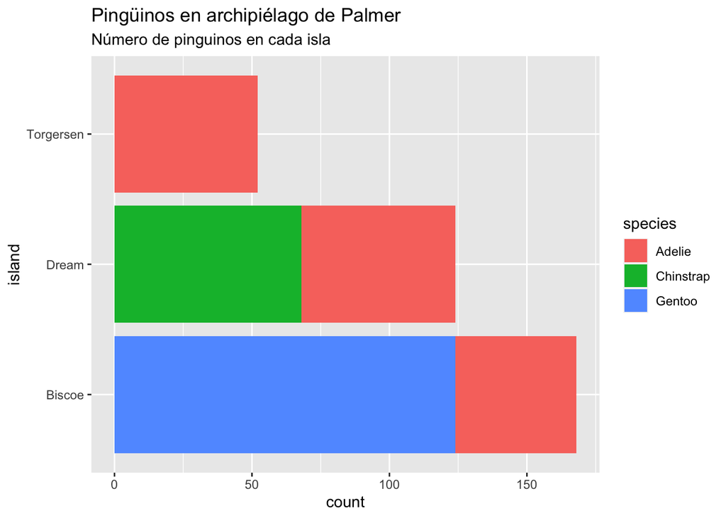

```r
barras1 <- ggplot(penguins, aes(y = island, fill = species)) +
  geom_bar() +
  labs(title = "Pingüinos en archipiélago de Palmer",
       subtitle = "Número de pinguinos en cada isla")

puntos1 <- ggplot(penguins, aes(x = bill_length_mm, y = bill_depth_mm,
                                color = species)) +
  geom_point() +
  labs(title = "Pingüinos en archipiélago de Palmer",
       subtitle = "Dimensiones del pico de diversas especies")

print(barras1)
```

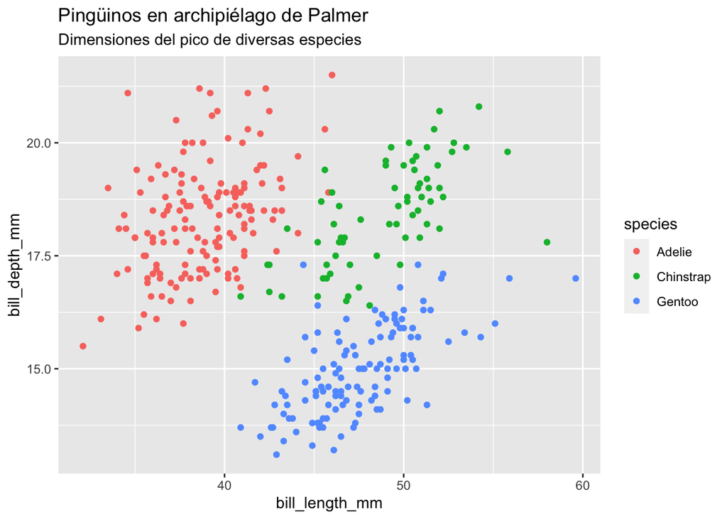

```r
print(puntos1)
```

## Crear tu propia paleta de colores

Ahora, a dejar volar la imaginación y crear una paleta de colores propias. Para esto utilizaremos paletteeer y el sitio web https://emilhvitfeldt.github.io/r-color-palettes/discrete.html nos ayudará para buscar paletas de colores ya hechas.

```r
paletteer_d("beyonce::X21")
```

```
## <colors>
## #171C45FF #3E2361FF #622E82FF #A45789FF #8EC87AFF #439E5FFF
```

```r
paletteer_d("beyonce::X13")
```

```
## <colors>
## #01213DFF #022A44FF #1D96BFFF #985F81FF #9B3257FF #480F1FFF
```

Ya tenemos diferentes códigos de colores. Podemos seleccionar los que más nos gusten y diseñar nuestra propia paleta de colores.

```r
paleta_octavia <- c("#622E82FF", "#A45789FF", "#9B3257FF", "#1D96BFF", "#8EC87AFF", "#439E5FFF")
```

Con nuestra paleta ya diseñada, podemos utilizarlas para los gráficos que hicimos anteriormente.

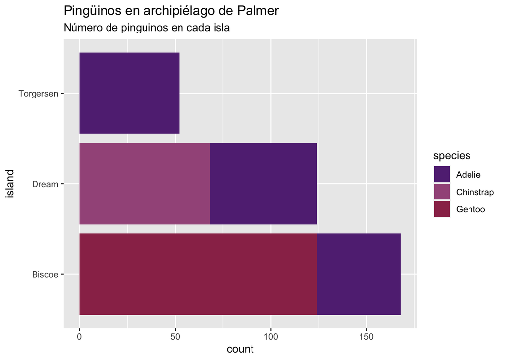

```r
barras1 + scale_fill_manual(values = paleta_octavia)
```

```r
puntos1 + scale_color_manual(values = paleta_octavia)
```

[output not shown]

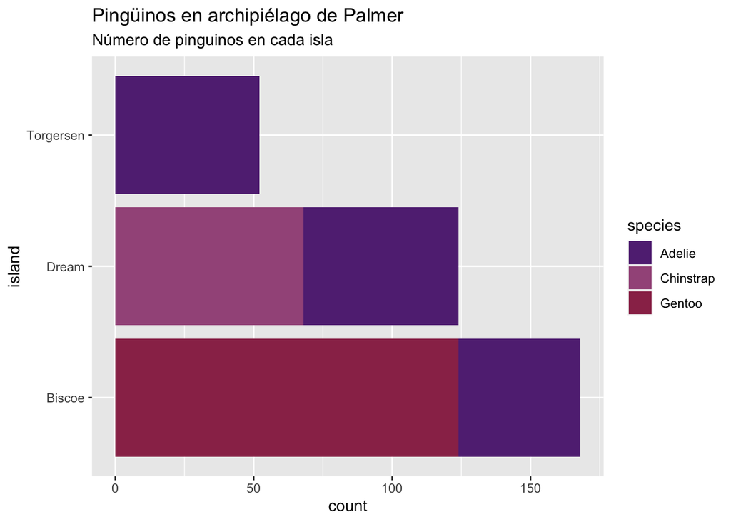

```r
mi_fill_1 <- scale_fill_manual(values = paleta_octavia)
mi_color_1 <- scale_color_manual(values = paleta_octavia)

barras1 + mi_fill_1
```

```r
puntos1 + mi_color_1
```

[output not shown]

## Crear paleta discreta

Con el mismo método anterior, creamos lo que se conoce como una paleta discreta. Haremos dos: una para el aesthetic “fill” y otra para “color”. Se puede seleccionar cualquier color que sea de nuestro agrado.

```r
library(paletteer)
paletteer_d("beyonce::X32")
```

```
## <colors>
## #D56702FF #EA8425FF #FCCD1BFF #EFE3D7FF #EFEFEFFF #DB1C6AFF
```

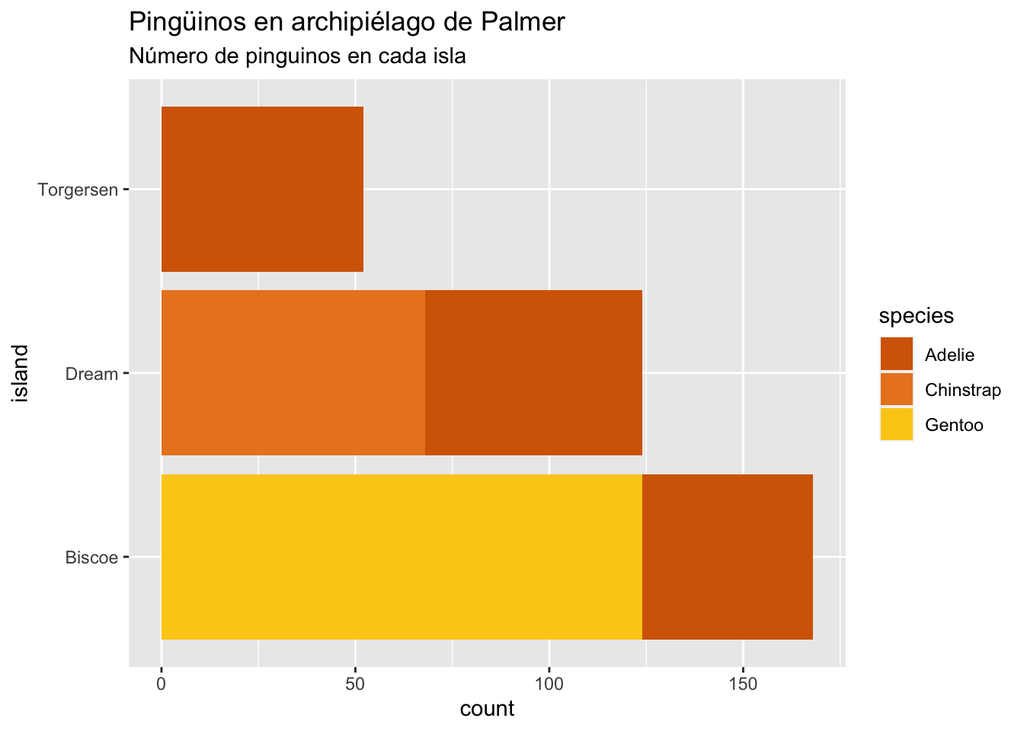

```r
paleta_discreta <- as.vector(paletteer_d("beyonce::X32"))

go_fill_1 <- scale_fill_manual(values = paleta_discreta)
go_color_1 <- scale_color_manual(values = paleta_discreta)

barras1 + go_fill_1
```

```r
puntos1 + mi_color_1
```

[output not shown]

## Cambiar temas y tamaños

Usando la información de este sitio https://ggplot2.tidyverse.org/articles/articles/faq-customising.html, cambiaremos el tamaño de la letra y del subtítulo de tus gráficos.

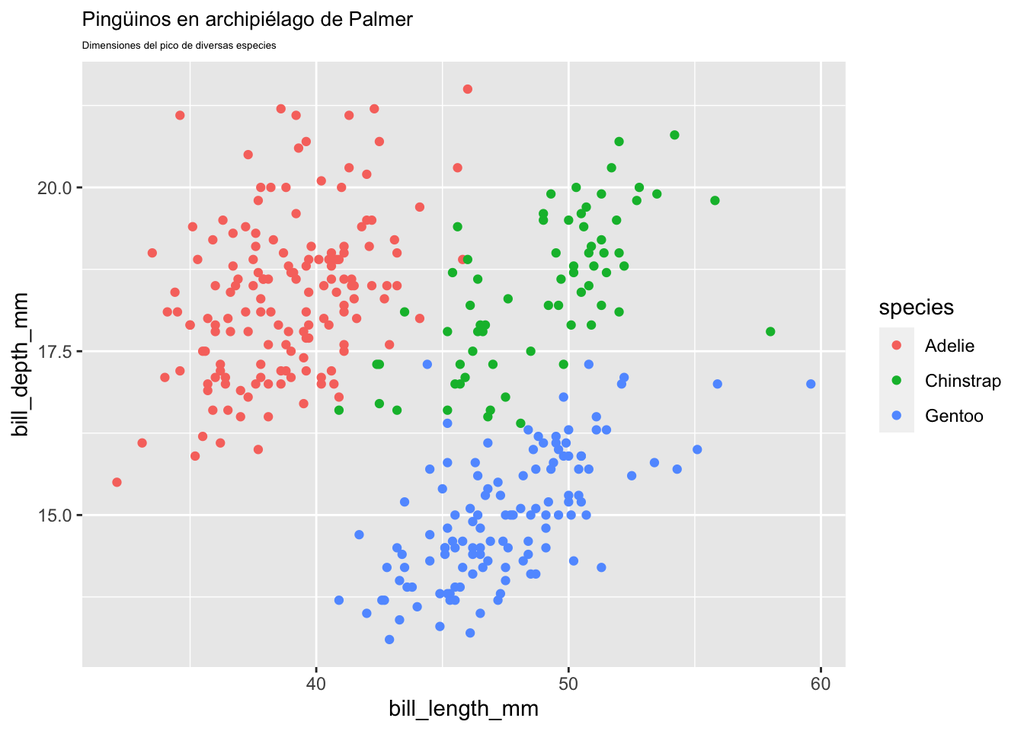

```r
puntos1 + theme(
  plot.title = element_text(size = 10),
  plot.subtitle = element_text(size = 5)
)
```

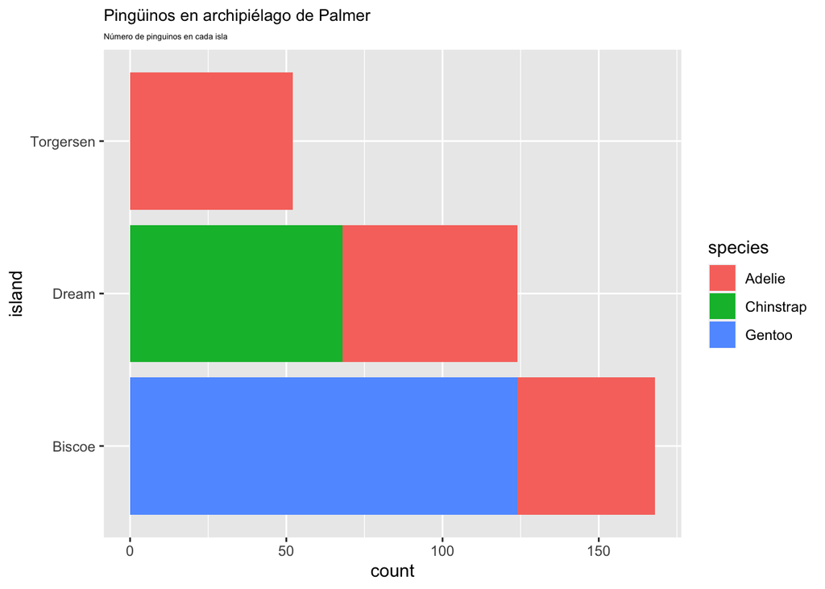

```r
barras1 + theme(
  plot.title = element_text(size=10),
  plot.subtitle = element_text(size = 5)
)
```

A continuación, y con la misma información, cambiaremos el color tanto del título como el subtítulo, manteniendo los nuevos tamaños de las letras.

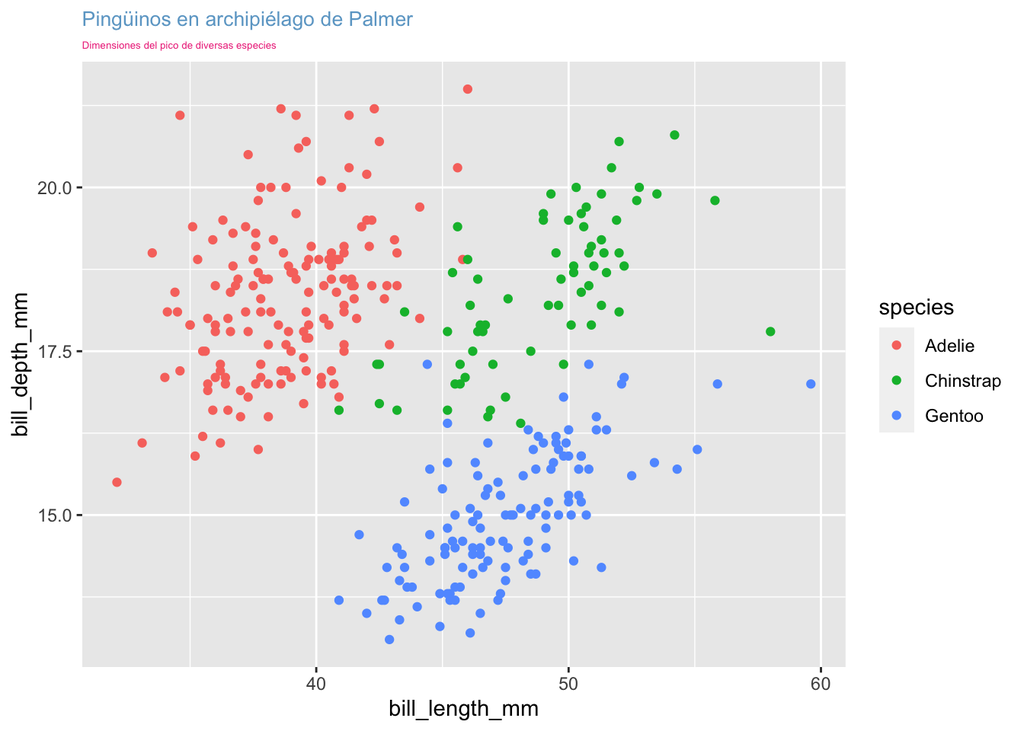

```r
puntos1 + theme(
  plot.title = element_text(size = 10, color = "skyblue3"),
  plot.subtitle = element_text(size = 5, color = "violetred2")
)
```

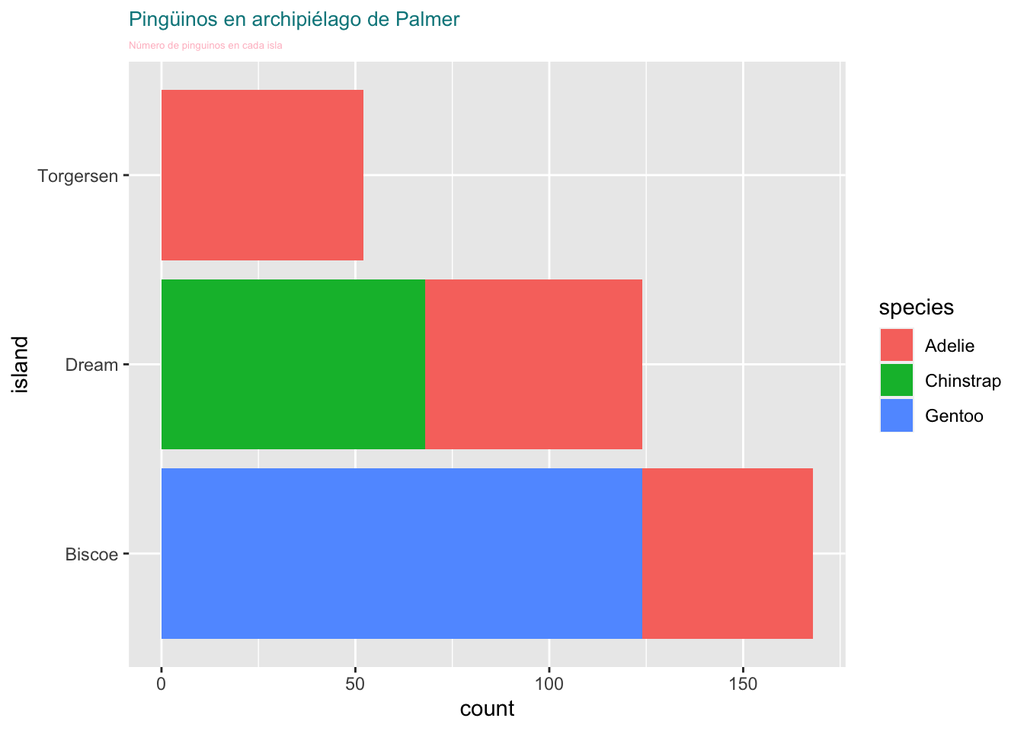

```r
barras1 + theme(
  plot.title = element_text(size = 10, color = "turquoise4"),
  plot.subtitle = element_text(size = 5, color = "pink")
)
```

## Eliminar elementos

Utilizando la información de https://ggplot2-book.org/polishing.html, eliminaremos el color del background del gráfico; y luego eliminaremos las grillas mayores y menores. Mantendremos los cambios realizados anteriormente.

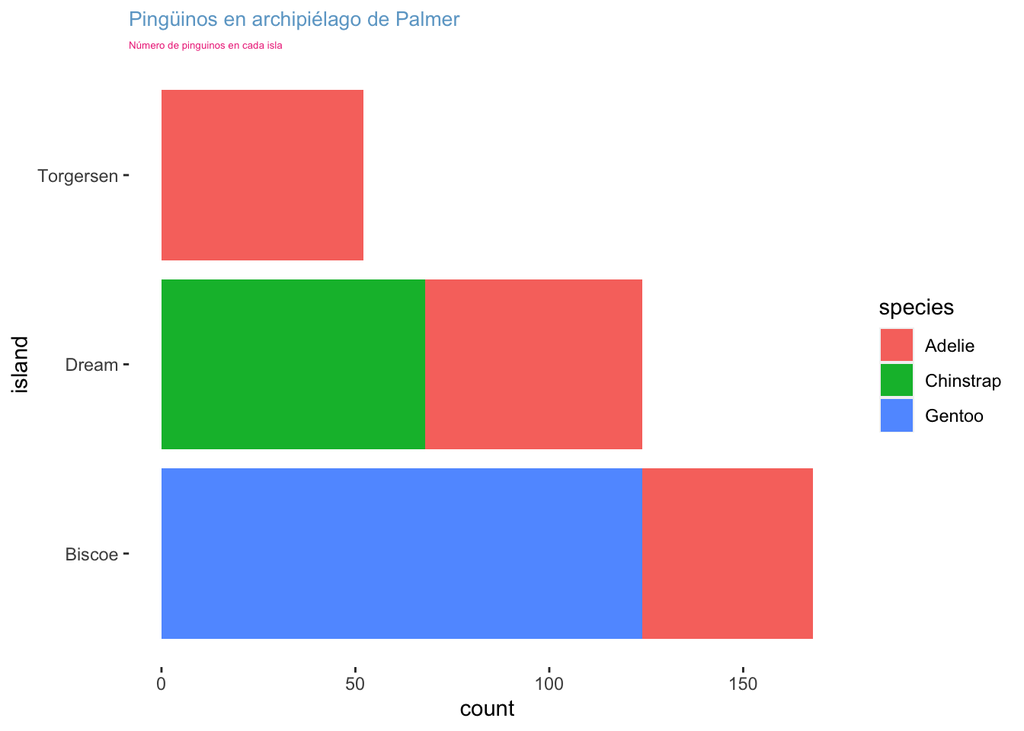

```r
barras1 + theme(panel.grid.major = element_blank(),
                panel.grid.minor = element_blank(),
                panel.background = element_blank(),
                plot.title = element_text(size = 10, color = "skyblue3"),
                plot.subtitle = element_text(size = 5, color = "violetred2"))
```

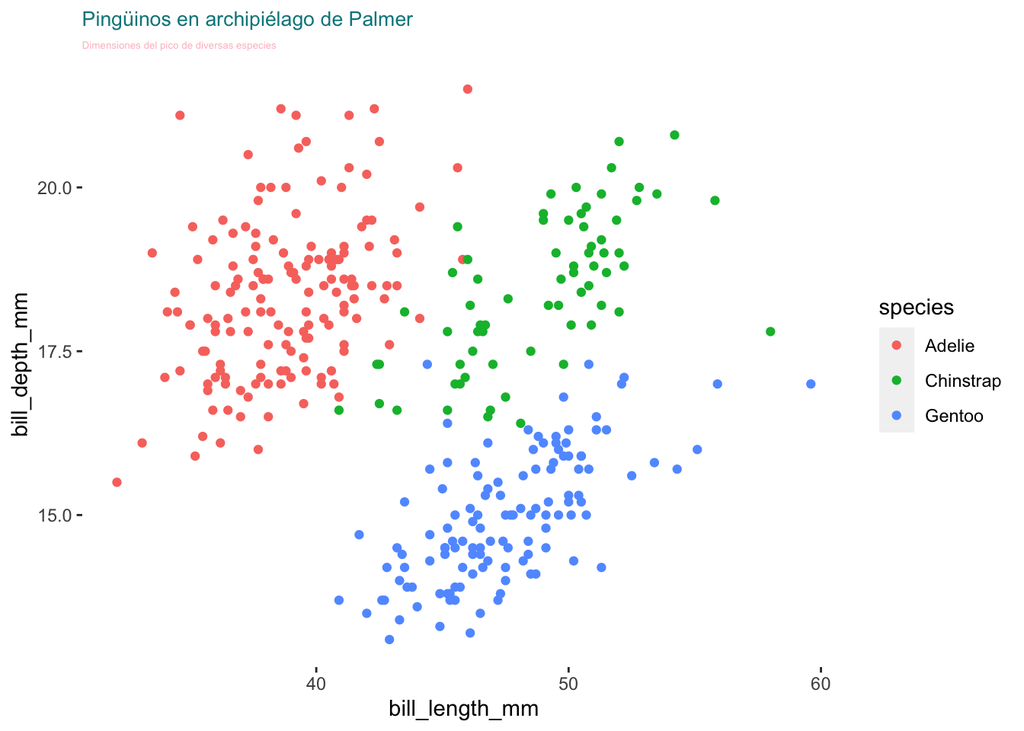

```r
puntos1 + theme(panel.grid.major = element_blank(),
                panel.grid.minor = element_blank(),
                panel.background = element_blank(),
                plot.title = element_text(size = 10, color = "turquoise4"),
                 plot.subtitle = element_text(size = 5, color = "pink"))
```

## Cambio de tema

El código realizado anteriormente, lo guardaremos con el nombre que estimes conveniente. Luego, aplicaremos esos cambios a los gráficos con el operador “+”.

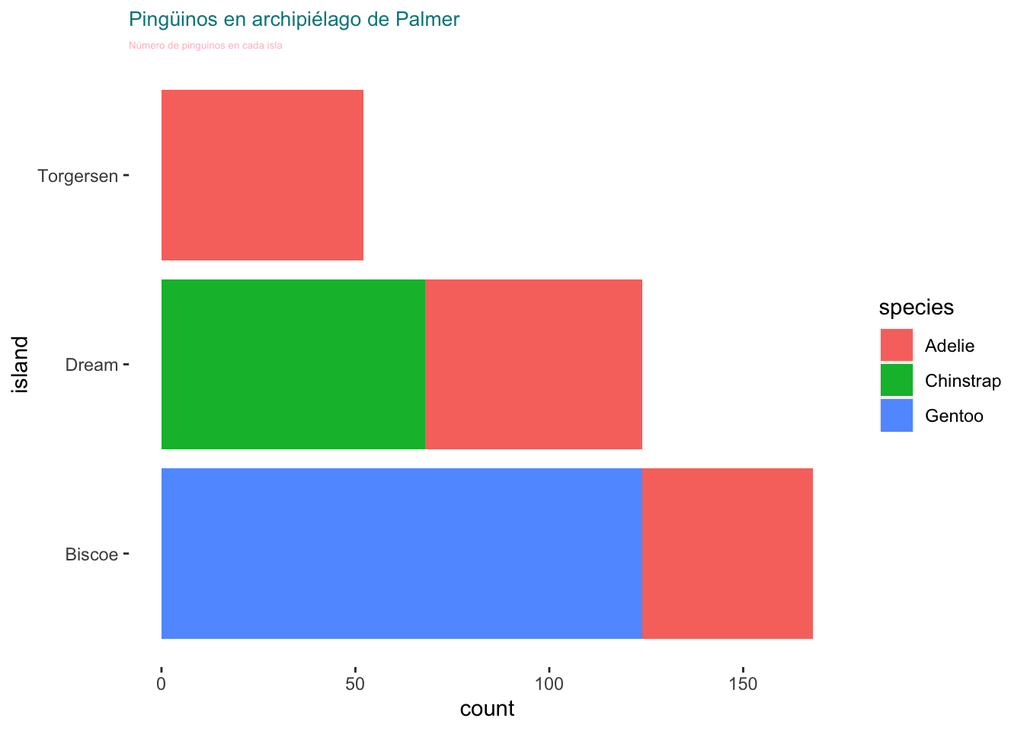

```r
cambio_tema <- theme(panel.grid.major = element_blank(),
                panel.grid.minor = element_blank(),
                panel.background = element_blank(),
                plot.title = element_text(size = 10, color = "turquoise4"),
                 plot.subtitle = element_text(size = 5, color = "pink"))

barras1 + cambio_tema
```

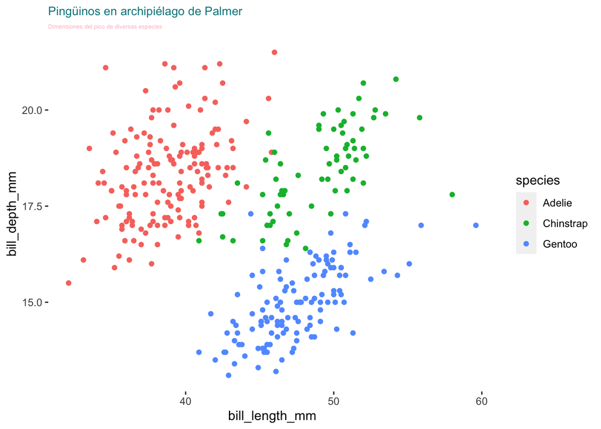

```r
puntos1 + cambio_tema
```